fossil

# Geometric de-noising, dug back up.

The authors' Matlab and the yeast test data were not lost after all: both turned up in web archives. We rebuilt the method in Python, checked it against their code, and ran every experiment again. Of 30 results, 1 came back exactly, 19 agree, 1 partly agree, 6 differ and 3 were not attempted.

See every result

## Install geodenoise

Python package

```
pip install "git+https://github.com/jeonglab-bcm/fossil#subdirectory=PMC2711306/package"
```

Python 3.10 or later, with NumPy and SciPy.

[README](https://github.com/jeonglab-bcm/fossil/blob/main/PMC2711306/package/README.md) [Tutorial](https://github.com/jeonglab-bcm/fossil/blob/main/PMC2711306/package/tutorial/TUTORIAL.md)

## Fig. 1

Fig. 1. Densities of embedded distances for edges (blue) and non-edges (red) in 5 dimensions: (A) yeast Yhigh, (B) human HumanBG.

Agrees

Published

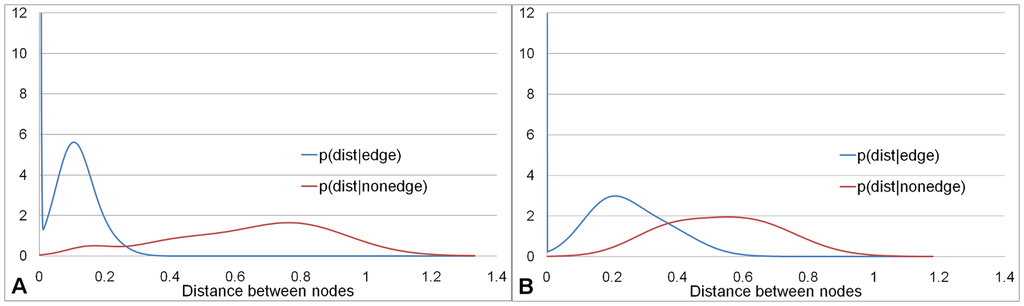

Our run

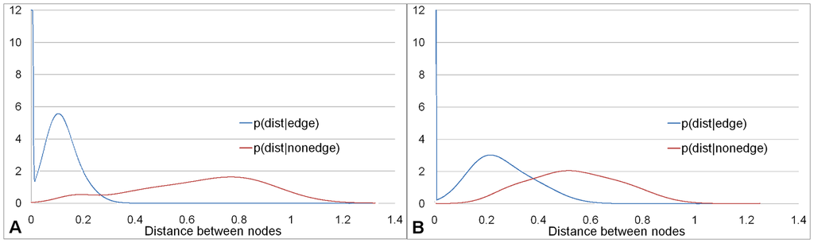

**Fig. 1A, densities of Yhigh distances in 5 dimensions**

97.6% within 2 px, Agrees

**Fig. 1B, densities of HumanBG distances in 5 dimensions**

69.9% within 2 px, Agrees on review (computed: partly)

The edge peak sits where it is published (0.20-0.21 over 20 seeds), but neither curve passes the mark (71% and 75% within 2 px): the non-edge density moves with the random training sample and EM start (its middle component's mean between 0.39 and 0.62 over 20 seeds). The embedding itself agrees (2,837 edges beyond 0.4 against 2,838).

## Fig. 2

Fig. 2. ROC curves on Yhigh for embedding dimensions 2 to 7, recovering Collins' low-confidence edges.

Agrees

Published

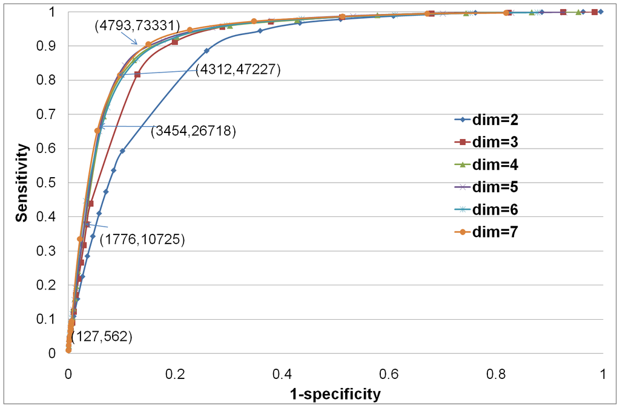

Our run

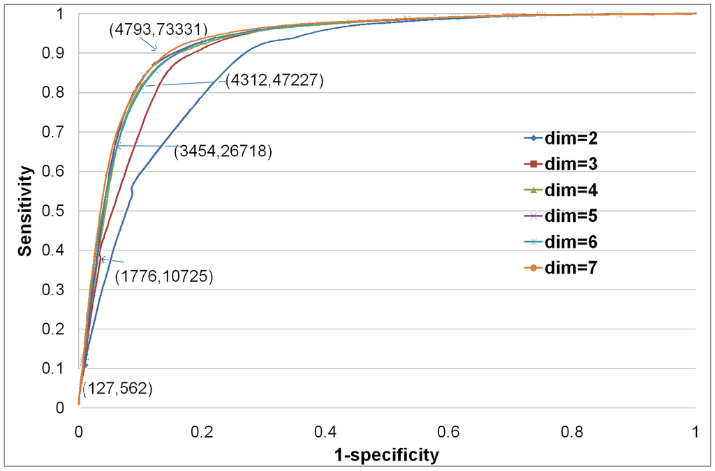

**Fig. 2, ROC curves on Yhigh for dimensions 2 to 7**

92.6% within 2 px, Agrees

## Fig. 3

Fig. 3. Precision against recall for the same runs.

Agrees

Published

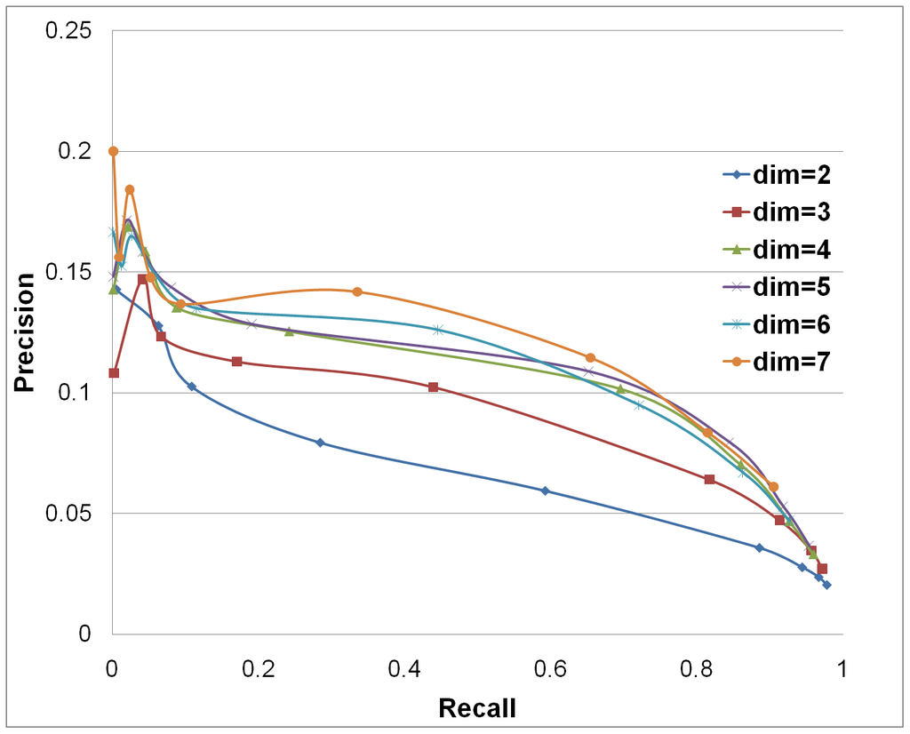

Our run

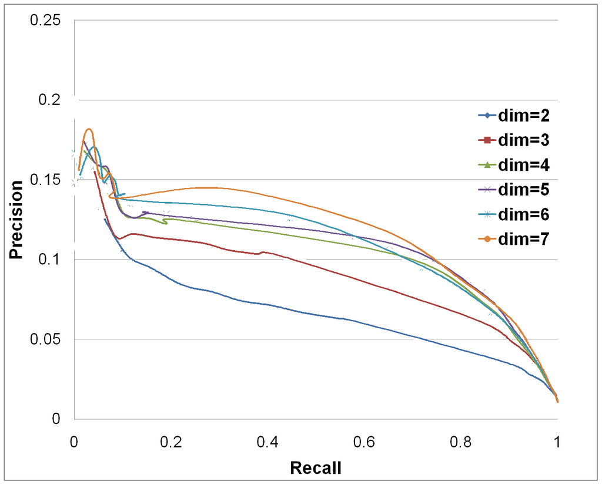

**Fig. 3, precision against recall on Yhigh for dimensions 2 to 7**

44.1% within 2 px, Agrees on review (computed: partly)

The curves have the published shapes and order, but precision is a ratio of small counts on a 0-0.25 axis: a 2% change in TP or FP moves a curve by 3-8 pixels, more than the 2-pixel tolerance. The counts differ by up to 6% (fig2.labels).

## Fig. 4

Fig. 4. Dimension 4: one iteration (blue) against iterating the embedding to convergence (red).

Agrees

Published

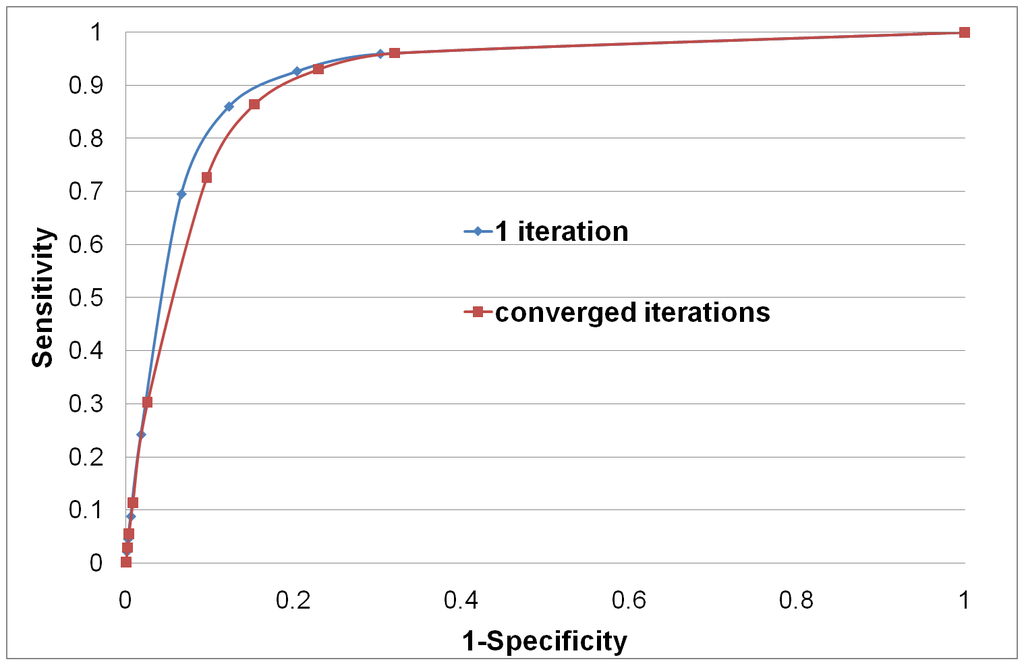

Our run

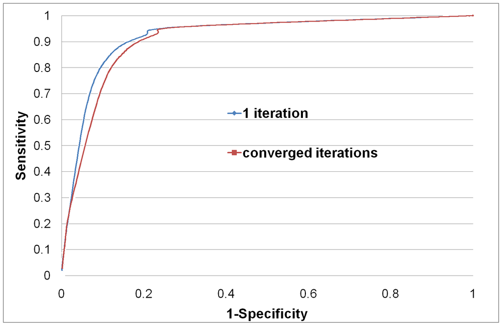

**Fig. 4, one iteration against iterating to convergence (dimension 4)**

95.1% within 2 px, Agrees

## Fig. 5

Fig. 5. ROC curves for recovering 500, 1,000, 2,000 and 3,000 edges deleted from Yhigh at random.

Agrees

Published

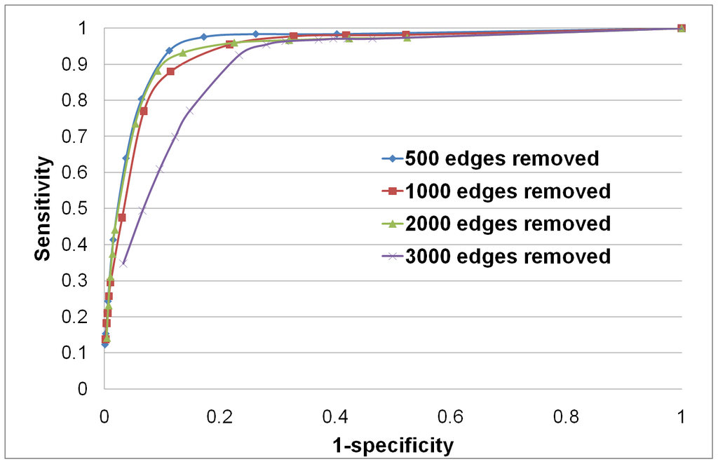

Our run

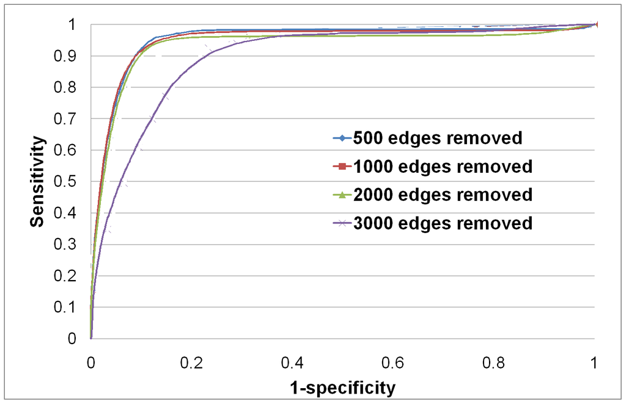

**Fig. 5, ROC for recovering 500 to 3,000 deleted Yhigh edges**

48.8% within 2 px, Agrees on review (computed: inconclusive)

Two settings that the paper does not state. The 3,000-edge curve was drawn from an embedding of every protein, cut-off ones included, while the 500 to 2,000 curves match an embedding of the largest component (the Methods say only the largest component is embedded). Drawn as the mean of 10 deletions' full ROC curves at the same false-positive rate, our curves lie on the published ones: mean vertical distance 0.007, 0.034, 0.006 and 0.012 for 500, 1,000, 2,000 and 3,000 edges over false-positive rates 0 to 0.5, and AUC 0.952, 0.948, 0.933 and 0.894 against 0.955, 0.938, 0.936 and 0.895 traced from the published curves. The pixel score is lower (48.8%) and does not beat the mean of the deletions' points at the same epsilon (50.1%), so the verdict is inconclusive. The published lines are Excel's smoothed lines through about ten markers, which cut below a dense ROC curve between markers: our mean curve read at ten points and smoothed the same way scores 61.5%. The published 1,000 curve lies lower than ours (0.034), and no setting we tested moves it there.

## Fig. S1

Fig. S1. p(edge|dist) for HumanBG, without the normalizing constant (one dot per protein pair within 0.4).

Agrees

Published

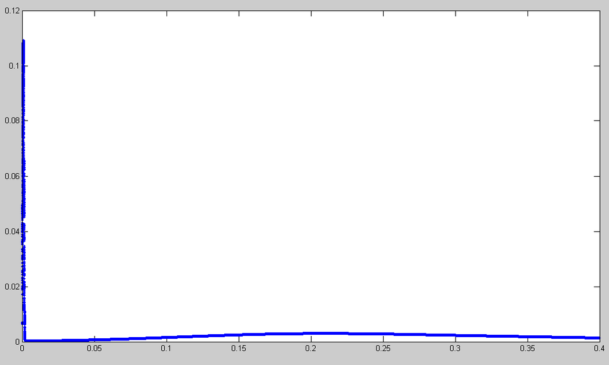

Our run

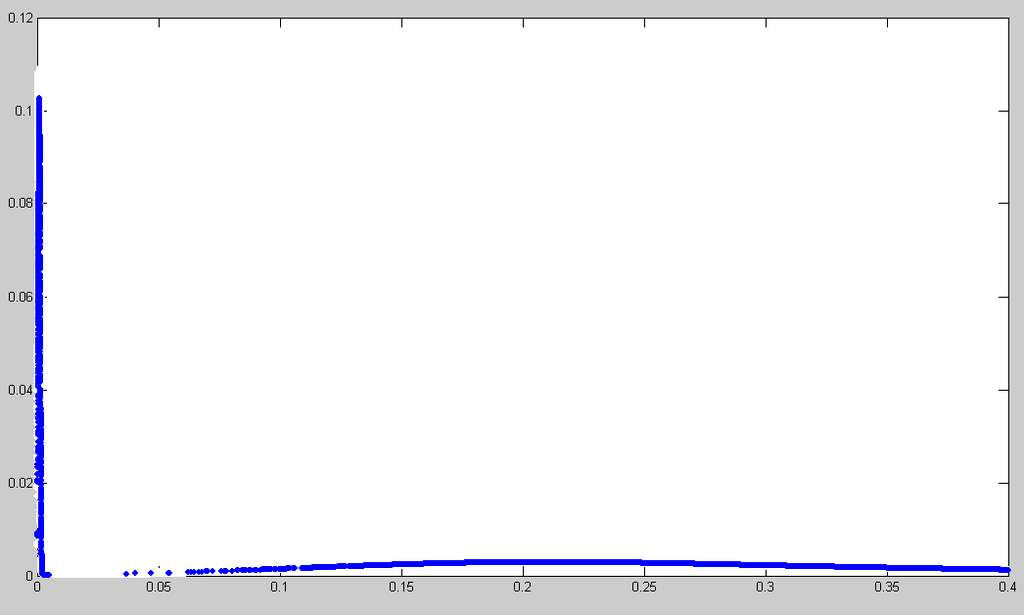

**Fig. S1, p(edge|dist) for HumanBG**

92.0% within 2 px, Agrees on review (computed: inconclusive)

Ours lies on the published points over 92% of them, far above the Yhigh densities (10%), but the same curve 5% higher scores as well (93.5%): on this axis (0 to 0.12) the comparison cannot resolve a 5% change in amplitude.

## Fig. S2

Fig. S2. p(nonedge|dist) for HumanBG, without the normalizing constant.

Agrees

Published

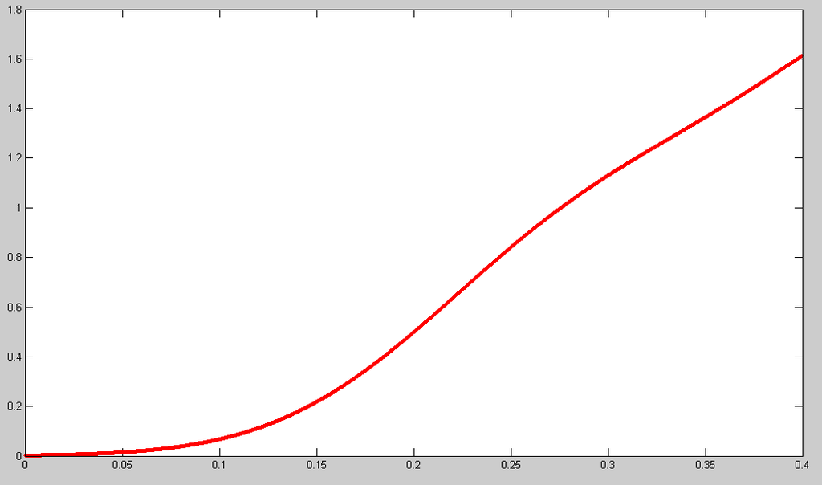

Our run

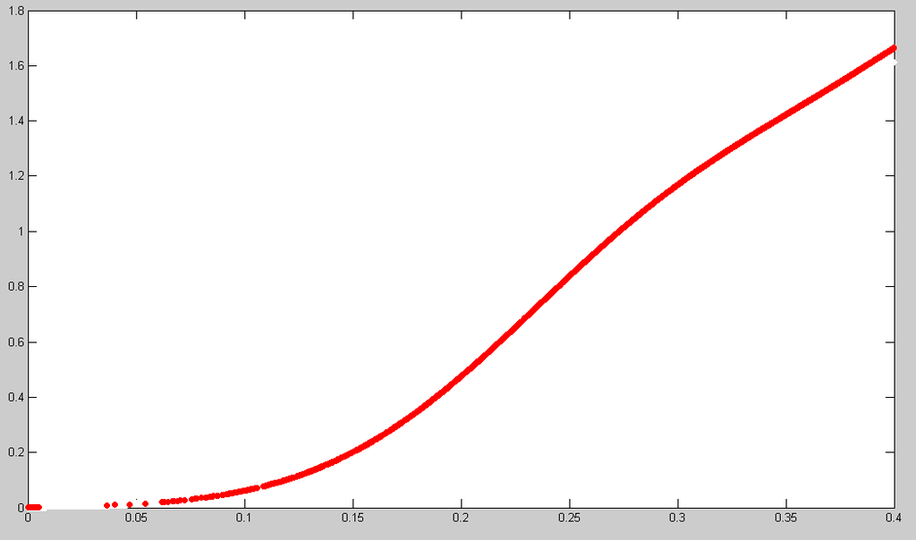

**Fig. S2, p(nonedge|dist) for HumanBG**

38.2% within 2 px, Agrees on review (computed: inconclusive)

The shape comes back (ours 47.7% and 38.2% within 2 px, the Yhigh densities 1.2%), but the non-edge density moves with the random training sample and EM start, and the curve 5% higher scores better (43.5%): the published fit differs from ours by a few percent of amplitude.

## Fig. S3

Fig. S3. Confidence score against distance for HumanBG.

Agrees

Published

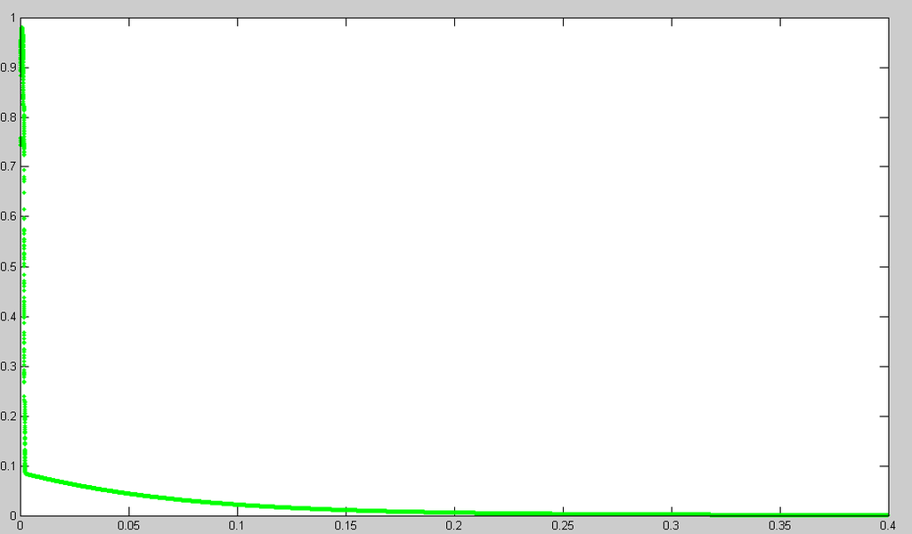

Our run

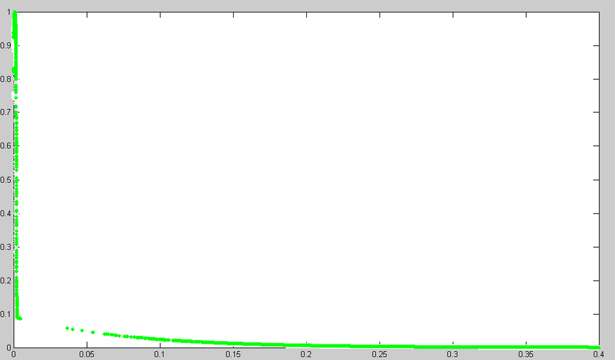

**Fig. S3, confidence score against distance for HumanBG**

89.2% within 2 px, Agrees on review (computed: inconclusive)

Ours lies on the published points over 89% of them, above the Yhigh densities (48%), but the posterior without division by its maximum and the curve 5% lower score as well (90.1%, 89.4%): the comparison cannot tell which of the two the figure shows.

## Every result

Every figure, table and number of the paper, in the paper's order. Paper and ours are both shown; the verdict is computed from them.

Result

Verdict

Measure

Why

Fig. 1A, densities of Yhigh distances in 5 dimensions

Agrees

97.6% within 2 px

Fig. 1B, densities of HumanBG distances in 5 dimensions

Agrees on review

69.9% within 2 px (computed partly; set to agrees by hyunhwan-bcm on review)

The edge peak sits where it is published (0.20-0.21 over 20 seeds), but neither curve passes the mark (71% and 75% within 2 px): the non-edge density moves with the random training sample and EM start (its middle component's mean between 0.39 and 0.62 over 20 seeds). The embedding itself agrees (2,837 edges beyond 0.4 against 2,838).

Fig. 2, ROC curves on Yhigh for dimensions 2 to 7

Agrees

92.6% within 2 px

Fig. 2, the (TP, FP) labels of the dimension 7 curve

Agrees on review

0 of 8 values (computed differs; set to agrees by hyunhwan-bcm on review)

- TP at epsilon 0.2: paper 1776, ours **1711**
- FP at epsilon 0.2: paper 10725, ours **10146**
- TP at epsilon 0.3: paper 3454, ours **3421**
- FP at epsilon 0.3: paper 26718, ours **25438**
- TP at epsilon 0.4: paper 4312, ours **4317**
- FP at epsilon 0.4: paper 47227, ours **45787**
- TP at epsilon 0.5: paper 4793, ours **4832**
- FP at epsilon 0.5: paper 73331, ours **71716**

Every count is within 6% of the paper's with Collins et al.'s own scores, and within 0.9% with BioGRID's copy of their high-confidence set. Neither copy has the paper's Yhigh (1,004 proteins and 8,323 edges against 1,004 and 8,319, or 1,002 and 8,313), and the low-confidence cut is inferred.

Fig. 3, precision against recall on Yhigh for dimensions 2 to 7

Agrees on review

44.1% within 2 px (computed partly; set to agrees by hyunhwan-bcm on review)

The curves have the published shapes and order, but precision is a ratio of small counts on a 0-0.25 axis: a 2% change in TP or FP moves a curve by 3-8 pixels, more than the 2-pixel tolerance. The counts differ by up to 6% (fig2.labels).

Fig. 4, one iteration against iterating to convergence (dimension 4)

Agrees

95.1% within 2 px

Fig. 5, ROC for recovering 500 to 3,000 deleted Yhigh edges

Agrees on review

48.8% within 2 px (computed inconclusive; set to agrees by hyunhwan-bcm on review)

Two settings that the paper does not state. The 3,000-edge curve was drawn from an embedding of every protein, cut-off ones included, while the 500 to 2,000 curves match an embedding of the largest component (the Methods say only the largest component is embedded). Drawn as the mean of 10 deletions' full ROC curves at the same false-positive rate, our curves lie on the published ones: mean vertical distance 0.007, 0.034, 0.006 and 0.012 for 500, 1,000, 2,000 and 3,000 edges over false-positive rates 0 to 0.5, and AUC 0.952, 0.948, 0.933 and 0.894 against 0.955, 0.938, 0.936 and 0.895 traced from the published curves. The pixel score is lower (48.8%) and does not beat the mean of the deletions' points at the same epsilon (50.1%), so the verdict is inconclusive. The published lines are Excel's smoothed lines through about ten markers, which cut below a dense ROC curve between markers: our mean curve read at ten points and smoothed the same way scores 61.5%. The published 1,000 curve lies lower than ours (0.034), and no setting we tested moves it there.

Fig. S1, p(edge|dist) for HumanBG

Agrees on review

92.0% within 2 px (computed inconclusive; set to agrees by hyunhwan-bcm on review)

Ours lies on the published points over 92% of them, far above the Yhigh densities (10%), but the same curve 5% higher scores as well (93.5%): on this axis (0 to 0.12) the comparison cannot resolve a 5% change in amplitude.

Fig. S2, p(nonedge|dist) for HumanBG

Agrees on review

38.2% within 2 px (computed inconclusive; set to agrees by hyunhwan-bcm on review)

The shape comes back (ours 47.7% and 38.2% within 2 px, the Yhigh densities 1.2%), but the non-edge density moves with the random training sample and EM start, and the curve 5% higher scores better (43.5%): the published fit differs from ours by a few percent of amplitude.

Fig. S3, confidence score against distance for HumanBG

Agrees on review

89.2% within 2 px (computed inconclusive; set to agrees by hyunhwan-bcm on review)

Ours lies on the published points over 89% of them, above the Yhigh densities (48%), but the posterior without division by its maximum and the curve 5% lower score as well (90.1%, 89.4%): the comparison cannot tell which of the two the figure shows.

Table 1, sensitivity and specificity of five published predictors

Not attempted

Values quoted from other papers; the paper's own row (90% and 85%) is the item text.yeast_performance.

Table S1, the 251 high-confidence predictions

Differs

0 of 2 values

- new pairs with CS >= 0.975: paper 251, ours **369**
- published pairs among ours: paper 251, ours **247**

Our run predicts 369 new pairs, including 247 of the 251 published ones (the other 4 involve proteins our HumanBG lacks). The count depends on the width of the EM spike at distance 0: over 20 seeds it is 253 to 386, and our seed (2009) gives the 19th highest of the 20.

Table S2 and text, predictions found in HPRD and BioGRID 2.0.50 (our predictions)

Differs

0 of 4 values

- predictions in HPRD: paper 12, ours **13**
- predictions in BioGRID 2.0.50: paper 5, ours **7**
- of those, also in HPRD: paper 4, ours **2**
- validated in either: paper 13, ours **18**

We predict 369 pairs rather than 251 (tableS1) and HPRD is a later release; the paper's own 251 pairs through our check give BioGRID 2.0.50 = 5 as printed and HPRD 11 against 12 (validation.published_pairs).

Table S3 and text, predictions sharing a GO BP or CC term (our predictions)

Differs

0 of 2 values

- pairs with both proteins annotated (BP or CC): paper 159, ours **237**
- pairs sharing a BP or CC term: paper 105, ours **159**

Counts scale with our 369 predictions; on the paper's 251 pairs our check gives 105 of 158 against 105 of 159.

Table S4 and text, predictions sharing a GO BP term (our predictions)

Differs

0 of 2 values

- pairs with both proteins annotated (BP): paper 129, ours **192**
- pairs sharing a BP term: paper 55, ours **75**

Counts scale with our 369 predictions; on the paper's 251 pairs our check gives 55 of 128 against 55 of 129.

Table S5 and text, predictions in the same KEGG pathway (our predictions)

Differs

0 of 2 values

- pairs with both proteins in a KEGG pathway: paper 26, ours **116**
- pairs in the same pathway: paper 12, ours **62**

KEGG of March 2009 is not freely archived; the current KEGG (372 human pathways against 205) puts many more of the paper's own pairs in pathways (80 against 26).

Table S6, predicted false positives (edges beyond 0.4 sharing no CC term)

Partly agrees on review

0 of 1 values (computed differs; set to partly by hyunhwan-bcm on review)

- predicted false positives: paper 1455, ours **1450**

1,450 pairs against 1,455, 1,421 of them the paper's: HumanBG differs by 6 edges and the GO release is our closest match, not the paper's.

Table S7, BioGRID systems treated as physical

Not attempted

An input definition; we use it to build HumanBG.

Network sizes in the text

Agrees on review

2 of 8 values (computed partly; set to agrees by hyunhwan-bcm on review)

- HumanBG proteins: paper 7930, ours **7792**
- HumanBG interactions: paper 23543, ours **23538**
- HumanBG largest component, proteins: paper 7513, ours **7514**
- HumanBG largest component, interactions: paper 23372, ours **23378**
- Collins high-confidence interactions: paper 9074, ours **9070**
- Collins high-confidence proteins: paper 1622, ours **1622**
- Yhigh proteins: paper 1004, ours **1004**
- Yhigh interactions: paper 8323, ours **8319**

HumanBG is rebuilt from BioGRID 2.0.35 to within 6 edges and 1 protein of the largest component; the whole network is 138 proteins short (how the paper counted proteins is not stated). The Collins scores we found give 9,070 high-confidence edges against 9,074.

AUC, sensitivity and precision on Yhigh (text, Table 1's own row)

Agrees on review

1 of 3 values (computed partly; set to agrees by hyunhwan-bcm on review)

- AUC, dimension 7: paper 0.9, ours **0.932**
- sensitivity at 85% specificity, dimension 7 (%): paper 90, ours **90.6**
- precision at recall 0.35, dimension 7: paper 0.15, ours **0.143**

AUC 0.932 (printed 0.9) comes back. Sensitivity at 85% specificity is 90.6% against 90%, within the few-percent difference of the counts (fig2.labels). 'Precision about 0.15 at recall about 0.35' rounds the paper's own dimension 7 marker at epsilon 0.2 (Fig. 3: 0.142 at 0.335); ours at that epsilon is 0.144 at 0.319, and 0.143 at recall exactly 0.35.

Dimension 2 is clearly worst; higher dimensions change little (text)

Agrees

2 of 2 values

- dimension 2 has the lowest AUC: paper yes, ours **yes**
- AUCs of dimensions 4 to 7 within 0.01 of each other: paper yes, ours **yes**

Iterating converges in about 10 iterations and is only slightly worse (text, Fig. 4)

Agrees on review

1 of 2 values (computed partly; set to agrees by hyunhwan-bcm on review)

- iterations to converge (median over epsilon 0.01 to 0.6): paper 10, ours **8**
- the converged ROC curve has the lower AUC (Fig. 4 points): paper yes, ours **yes**

The paper gives no stopping rule. Ours (stop when no new pair is predicted) takes 6 to 14 iterations over epsilon 0.01 to 0.6, median 8, against 'about 10, depending on the network and the dimension' (from 0.7 the graph fills up and the embedding collapses after 2). The converged ROC curve lies just under the first, as printed (AUC on the drawn points 0.904 against 0.916).

Candidate false positives (text)

Agrees on review

3 of 4 values (computed partly; set to agrees by hyunhwan-bcm on review)

- edges further apart than 0.4: paper 2838, ours **2837**
- share of all edges (%): paper 12, ours **12**
- edges sharing a CC term, of those with both proteins annotated (%): paper 72, ours **72**
- candidates sharing a CC term, of those annotated (%): paper 66, ours **66**

2,837 edges beyond 0.4 against 2,838: our HumanBG has 6 more edges. The shares sharing a CC term are taken over edges whose two proteins both have a CC term (72% and 66%, as printed); over all edges they would be 54% and 49%.

Pairs with CS >= 0.975: 1,685, of them 1,434 edges and 251 new (text)

Differs

0 of 3 values

- pairs with CS >= 0.975: paper 1685, ours **2292**
- of them edges: paper 1434, ours **1923**
- of them new: paper 251, ours **369**

The count depends on the EM spike at distance 0, which moves with the random training sample: over 20 seeds 1,679 to 2,361 pairs (the paper's 1,685 is inside) and 253 to 386 new ones.

GO background counts of Text S1 (HumanBG proteins annotated, pairs sharing a term)

Agrees on review

0 of 4 values (computed differs; set to agrees by hyunhwan-bcm on review)

- HumanBG proteins with a BP or CC term: paper 6278, ours **6292**
- pairs of them sharing a term (K): paper 7400424, ours **7428577**
- HumanBG proteins with a BP term: paper 5864, ours **5877**
- pairs of them sharing a BP term (K): paper 1354495, ours **1358313**

GOA release 70 gives 6,292 annotated proteins against 6,278 (0.2%) and 5,877 against 5,864; the exact release and filters are not given.

The paper's Table S1 through our validation code (BioGRID 2.0.50, HPRD, GO, KEGG)

Agrees on review

3 of 8 values (computed partly; set to agrees by hyunhwan-bcm on review)

- in BioGRID 2.0.50: paper 5, ours **5**
- in HPRD: paper 12, ours **11**
- annotated (BP or CC): paper 159, ours **158**
- sharing a BP or CC term: paper 105, ours **105**
- annotated (BP): paper 129, ours **128**
- sharing a BP term: paper 55, ours **55**
- both proteins in a KEGG pathway: paper 26, ours **80**
- in the same KEGG pathway: paper 12, ours **42**

BioGRID 2.0.50 and the GO 'sharing' counts come back as printed; the annotated counts are one short (GO release), HPRD one short (release 9 for the 2009 release), KEGG far higher (current KEGG).

Claims recomputed from the paper's own numbers (Text S1 p-values, ratios)

Exact

13 of 17 values

- pairs among 7,513 HumanBG proteins (Text S1 M): paper 28218828, ours **28218828**
- pairs among 6,278 GO BP/CC-annotated proteins (M): paper 19703503, ours **19703503**
- pairs among 5,864 GO BP-annotated proteins (M): paper 17190316, ours **17190316**
- HPRD p-value, Text S1 (12 of 251, K = 34,119): paper 7.5e-8, ours **7.5e-16**
- HPRD p-value, main text: paper 7e-8, ours **7e-16**
- GO BP or CC p-value (105 of 159): paper 7.26e-8, ours **3.38e-13**
- GO BP p-value (55 of 129): paper 1.4e-8, ours **6.2e-27**
- annotated pairs, 251 - 92: paper 159, ours **159**
- share of GO-annotated predictions sharing a term (%): paper 66, ours **66**
- high-confidence pairs, 1,434 edges + 251 new: paper 1685, ours **1685**
- candidate false positives, share of edges (%): paper 12, ours **12**
- KEGG: predictions with both proteins in a pathway (% of 251): paper 10, ours **10**
- KEGG: same pathway (% of 26): paper 46, ours **46**
- KEGG: same pathway (% of 251), 'about 5%': paper 5, ours **5**
- validated in HPRD or BioGRID 2.0.50: 12 + 5 - 4: paper 13, ours **13**
- recall 0.35 of 154,000 human interactions: paper 53900, ours **53900**
- Collins: 12,122 - 7,504 kept, + 4,456 new: paper 9074, ours **9074**

32 of 251 predictions co-mentioned in PubMed abstracts (CiteXplorer)

Not attempted

CiteXplorer was retired; its successor (Europe PMC) indexes a different, larger literature, so a count today does not test the 2009 one.

Port against the authors' Matlab embedding (embed_novi.m under GNU Octave)

Agrees

Python package geodenoise and its tutorial

Agrees

The paper's main claim holds: the embedding recovers Collins' low-confidence yeast edges with AUC 0.93 and finds the human predictions of Table S1 (247 of 251). Some counts differ; the causes are the random EM fit behind the 0.975 cut, the later GO, HPRD and KEGG releases, and copies of the yeast data that differ from the paper's by a few edges.

## What came back

**The code**

embed_novi.m, assign_scores.m and EM.m were on the Wayback Machine (kuchaev.com/Denoising, 2016). They hold the settings the paper leaves out: path lengths up to 29, unreachable pairs at 200, each axis rescaled to [0, 1], P(edge) = 0.001.

**The yeast test data**

Collins et al.'s PE scores for all 401,820 pairs were on the Wayback Machine too (interactome-cmp.ucsf.edu, 2010). PE >= 3.19 gives Yhigh with the paper's 1,004 proteins.

**The low-confidence edges**

Pairs with 1.85 <= PE < 3.19, the cut Collins et al. used for clustering, give ROC curves on the published markers (Fig. 2); the labelled counts are 0.1% to 5.4% off.

**The epsilon grid**

The markers of Fig. 2 sit at epsilon 0.01 to 0.1 and 0.2 to 1.4; our points at the same epsilons land on them.

**Fig. 5's 3,000 curve**

It was embedded with every protein, including those the deletion cut off (the other three curves only the largest component), and each size is a mean of full ROC curves at the same false-positive rate. Drawn that way, our four curves lie within 0.006 to 0.034 of the published ones and the 3,000 curve's AUC is 0.894 (published 0.895).

**Iterating**

Re-embedding with the predictions added converges in 6 to 14 rounds (the paper says about 10) and costs a little accuracy, as in Fig. 4.

**HumanBG**

BioGRID 2.0.35 keyed by upper-cased symbol: 7,514 proteins and 23,378 edges in the largest component (paper 7,513 and 23,372), and 2,837 edges further apart than 0.4 (paper 2,838).

## What stayed buried

- The paper's exact copy of the Collins high-confidence set (9,074 edges; the web copy has 9,070, BioGRID's 9,064)
- The random training sample and EM start behind the 0.975 cut (1,685 pairs; ours range from 1,679 to 2,361 over 20 seeds)
- The HPRD release of 2009 and KEGG of March 2009
- CiteXplorer, retired
- How Fig. 5's curves were embedded and averaged (its 3,000 curve keeps the proteins the deletion cut off, the others do not)
- The p-values of Text S1: they do not follow from its own parameters (7.5e-8 should read 7.5e-16; the GO values are 3.4e-13 and 6.2e-27)

The paper's main claim holds: the embedding recovers Collins' low-confidence yeast edges with AUC 0.93 and finds the human predictions of Table S1 (247 of 251). Some counts differ; the causes are the random EM fit behind the 0.975 cut, the later GO, HPRD and KEGG releases, and copies of the yeast data that differ from the paper's by a few edges.

## What we matched

Where the inputs are the paper's own, the numbers come back.

**Fig. 1A**

The Yhigh densities overlay the published curves (spike at 0, peak at 0.1, non-edge mode at 0.77).

**Fig. 2**

Six ROC curves on the published grid; AUC 0.93 at dimension 7.

**Fig. 4**

Both curves on the published markers.

**Table S1**

247 of the 251 published pairs are among our high-confidence predictions; the other 4 involve proteins our HumanBG lacks.

**BioGRID 2.0.50**

The paper's own 251 pairs give 5 matches in BioGRID 2.0.50, as printed.

## The session

The reproduction was done by an AI agent, Claude Code, in one session. Every prompt, reply and tool call of it is published.

**Wall clock**

7.3 days

first message to last, waits included

**Human prompts**

16

messages typed by a person

**Tool calls**

517

24 of them in subagents

**Tokens**

143.3 M

every request, subagents included

Read the session [The raw files](https://github.com/jeonglab-bcm/fossil/tree/main/PMC2711306/session)